# classificacao-e-classificadores-gaussianos

## Aprendizado de Máquina I

### Gabriel Sanfins

#### `gabrielsanfins@id.uff.br`

### 08 Classificação e classificadores gaussianos

# Classificação supervisionada sob a ótica da modelagem dos dados

## Formulação do problema

- $\mathbf{X}$ vetor aleatório em $\mathbb{R}^p$ - *preditores* ou *atributos* (*features*)
- $\mathcal{C}$ conjunto finito - *rótulos*
- $Y$ variável aleatória em $\mathcal{C}$ finito
- Distribuição de probabilidade conjunta para $(\mathbf{X}, Y)$
- Observações $(\mathbf{X}_1, Y_1), \dots, (\mathbf{X}_n, Y_n), \dots \sim (\mathbf{X}, Y)$ iid

## Formulação do problema

- Problema de **predição**: A partir de observações $(\mathbf{x}_i, y_i)_{i = 1, \dots, n}$ encontrar $g: \mathbb{R}^p \to \mathcal{C}$ (dito o *classificador*) tal que
  $$``g(\mathbf{x}_{n + 1}) \approx y_{n + 1}, \dots, g(\mathbf{x}_{n + m}) \approx y_{n + m}"$$
- Como formular tal pergunta sem aspas?
- Como encontrar tal $g$?

## Formulação do problema

- *Risco esperado* associado à $g$:
  $$R(g) = \mathbb{E}[\underbrace{(Y - g(\mathbf{X}))^2}_{L(g; (\mathbf{X}, Y))}]$$
- “Basta” encontrar $g$ que minimiza tal quantidade! :-)
- Tal procedimento é impossível… requer conhecimento completo do modelo probabilístico que relaciona $\mathbf{X}$ com $Y$!
- Além disso, a *perda quadrática* $L(g; (\mathbf{X}, Y)) = (Y - g(\mathbf{X}))^2$ não faz sentido no problema de classificação!

## Formulação do problema

- Podemos trocar
  $$``g(\mathbf{x}_{i}) \approx y_{i}"$$
  por
  $$g(\mathbf{x}_{i}) = y_{i} \implies \text{:-)} \\ g(\mathbf{x}_{i}) \neq y_{i} \implies \text{:-(}$$

## Formulação do problema

- Uma função perda razoável parece ser
  $$L(g; (\mathbf{X}, Y)) = \mathbb{I}(Y \neq g(\mathbf{X})) = \begin{cases} 0, &\text{ se } Y = g(\mathbf{X}) \\ 1, &\text{ se } Y \neq g(\mathbf{X}) \end{cases}$$
- Sua respectiva função risco é dada por
  $$R(g) = \mathbb{E}[\mathbb{I}(Y \neq g(\mathbf{X}))] = \mathbb{P}(Y \neq g(\mathbf{X}))$$
- Qual classificador $g$ minimiza tal probabilidade?

## O classificador de Bayes

**Teorema**: A função $g: \mathbb{R}^p \to \mathcal{C}$ que minimiza o risco
$$R(g) = \mathbb{E}[\mathbb{I}(Y \neq g(\mathbf{X}))] = \mathbb{P}(Y \neq g(\mathbf{X}))$$
é o *classificador de Bayes*, dado por
$$g(\mathbf{x}) = \mathop{\mathrm{argmax}}_{d \in \mathcal{C}} \mathbb{P}(Y = d | \mathbf{X} = \mathbf{x})$$

- Classificamos $\mathbf{x}$ com a classe que possui a maior probabilidade *a posteriori*
- Porém, $\mathbb{P}(Y = d | \mathbf{X} = \mathbf{x})$ é em geral desconhecida

## Classifidadores *plug-in*

- Estimar $\mathbb{P}(Y = d | \mathbf{X} = \mathbf{x})$ para cada classe $d \in \mathcal{C}$
- Considerar o classificador
  $$g(\mathbf{x}) = \mathop{\mathrm{argmax}}_{d \in \mathcal{C}} \widehat{\mathbb{P}}(Y = d | \mathbf{X} = \mathbf{x})$$
- Alguns exemplos:
  - Bayes ingênuo (*Naive Bayes*)
  - LDA/QDA
  - Regressão logística

# Classificador ingênuo de Bayes (*Naive Bayes*)

## Classificador *Naive Bayes*: atributos contínuos

- $\mathbf{X} \in \mathbb{R}^p$ vetor de atributos - vetor aleatório contínuo com densidade $q(\mathbf{x})$:
  $$\mathbb{P}(Y = d | \mathbf{X} = \mathbf{x}) = \frac{q(\mathbf{x} | Y = d)\mathbb{P}(Y = d)}{\sum_{c \in \mathcal{C}} q(\mathbf{x} | Y = c)\mathbb{P}(Y = c)}$$
- $\mathbb{P}(Y = d)$ estimado através da proporção amostral entre as classes

## Classificador *Naive Bayes*: atributos contínuos

- Assumir algum modelo probabilístico em $\mathbf{X}$ para estimar $q(\mathbf{x} | Y = d)$
- Para toda classe $d \in \mathcal{C}$, fatoramos
  $$q(\mathbf{x} | Y = d) = q(x_1, \dots, x_p | Y = d) = \prod_{j = 1}^{p} q(x_j | Y = d)$$
- *Condicionalmente à classe* $Y$, as componentes de $\mathbf{X}$ são independentes: hipótese *ingênua* - daí o nome!

## Classificador *Naive Bayes*: atributos contínuos

- Para toda classe $d \in \mathcal{C}$, fatoramos
  $$q(\mathbf{x} | Y = d) = q(x_1, \dots, x_p | Y = d) = \prod_{j = 1}^{p} q(x_j | Y = d)$$
- $q(x_j | Y = d)$ pode ser qualquer distribuição de interesse
- Importância da análise exploratória preliminar!
- Importância de um bom “cinturão de utilidades” de modelos probabilísticos!

## Classificador *Naive Bayes*: atributos contínuos

- Estimação de parâmetros (ou da forma de) $q(x_j | Y = d)$:
  - Observações referentes ao atributo $X_j$…
  - …pertencentes à classe $d$
  - $\Rightarrow$ ferramentas de Inferência Estatística!
  - Ou Inferência Não-Paramétrica, se for necessário
- No `scikit-learn`:
  - [`GaussianNB`](https://scikit-learn.org/stable/modules/generated/sklearn.naive_bayes.GaussianNB.html): $X_j | (Y = d) \sim \mathrm{N}(\mu_{j, d}, \sigma_{j, d}^2)$

## Classificador *Naive Bayes*: atributos discretos

- Se $\mathbf{X}$ é discreto, temos que:
  $$\mathbb{P}(Y = d | \mathbf{X} = \mathbf{x}) = \frac{\mathbb{P}(\mathbf{X} = \mathbf{x} | Y = d)\mathbb{P}(Y = d)}{\sum_{c \in \mathcal{C}} \mathbb{P}(\mathbf{X} = \mathbf{x} | Y = c)\mathbb{P}(Y = c)}$$
- $\mathbb{P}(Y = d)$ estimado através da proporção amostral entre as classes
- Assumir algum modelo probabilístico em $\mathbf{X}$ para estimar $\mathbb{P}(\mathbf{X} = \mathbf{x} | Y = d)$

## Classificador *Naive Bayes*: atributos discretos

- Para toda classe $d \in \mathcal{C}$, fatoramos
  $$\mathbb{P}(\mathbf{X} = \mathbf{x} | Y = d) = \mathbb{P}(X_1 = x_1, \dots, X_p = x_p | Y = d)$$
  $$= \prod_{j = 1}^{p} \mathbb{P}(X_j = x_j | Y = d)$$
- *Condicionalmente à classe* $Y$, as componentes de $\mathbf{X}$ são independentes: hipótese *ingênua*!

## Classificador *Naive Bayes*: atributos discretos

- Estimação de parâmetros análoga ao caso contínuo
- No `scikit-learn`:
  - [`BernoulliNB`](https://scikit-learn.org/stable/modules/generated/sklearn.naive_bayes.BernoulliNB.html): $X_j | (Y = d) \sim \mathrm{Bern}(p_{j, d})$
  - [`CategoricalNB`](https://scikit-learn.org/stable/modules/generated/sklearn.naive_bayes.CategoricalNB.html): $X_j | (Y = d) \sim \mathrm{Cat}(k, p_1, \dots, p_k)$
  - [`ComplementNB`](https://scikit-learn.org/stable/modules/generated/sklearn.naive_bayes.ComplementNB.html): Aprimoramento do `MultinomialNB`
  - [`MultinomialNB`](https://scikit-learn.org/stable/modules/generated/sklearn.naive_bayes.MultinomialNB.html): Não assume independência! $\mathbf{X} | (Y = d) \sim \mathrm{Multi}(n, k, p_1, \dots, p_k)$

# Análise de discriminante: linear e quadrático (LDA/QDA)

## Recapitulando

- **Teorema** (Classificador de Bayes): A função $g: \mathbb{R}^p \to \mathcal{C}$ que minimiza o risco
  $$R(g) = \mathbb{E}[\mathbb{I}(Y \neq g(\mathbf{X}))] = \mathbb{P}(Y \neq g(\mathbf{X}))$$
  é o *classificador de Bayes*, dado por
  $$g(\mathbf{x}) = \mathop{\mathrm{argmax}}_{d \in \mathcal{C}} \mathbb{P}(Y = d | \mathbf{X} = \mathbf{x})$$

## Recapitulando

- Se $\mathbf{X}$ é contínuo com densidade $q(\mathbf{x})$, temos que:
  $$\mathbb{P}(Y = d | \mathbf{X} = \mathbf{x}) \propto q(\mathbf{x} | Y = d)\mathbb{P}(Y = d)$$
- Análise de discriminante: Não assumir independência nas componentes de $\mathbf{X} | (Y = d)$, mas que seguem uma **normal multivariada** mais geral

## A distribuição normal multivariada

$$\begin{align*} \mathbf{Z} \sim &N(\boldsymbol{\mu}, \boldsymbol{\Sigma}) \iff \\ &p(\mathbf{z}) = \frac{1}{\sqrt{(2 \pi)^p \det(\boldsymbol{\Sigma})}} \times \\ &\quad\quad\quad\exp\left(-\frac{1}{2} (\mathbf{z} - \boldsymbol{\mu})^T \boldsymbol{\Sigma}^{-1} (\mathbf{z} - \boldsymbol{\mu})\right) \end{align*}$$
onde $\mathbf{z}, \boldsymbol{\mu} \in \mathbb{R}^p$ e $\boldsymbol{\Sigma}$ é uma matriz $p \times p$ simétrica positiva-definida

## A distribuição normal multivariada

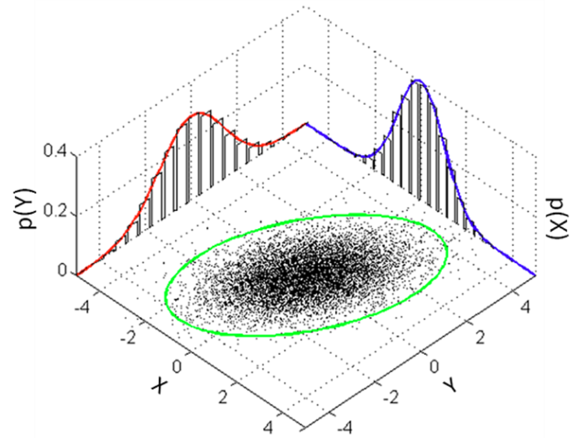

[Wikipedia] Dados de uma normal bivariada com $\boldsymbol{\mu} = \begin{bmatrix} 0 \\ 0\end{bmatrix}$ e $\boldsymbol{\Sigma} = \begin{bmatrix} 1 & 3/5 \\ 3/5 & 2\end{bmatrix}$.

## Análise de discriminante linear (LDA)

- Cada $\mathbf{X} | (Y = d)$ pode ter médias distintas **porém as classes compartilham a mesma matriz de covariância**:
  $$\mathbf{X} | (Y = d) \sim N(\boldsymbol{\mu}_d, \boldsymbol{\Sigma})$$
- Parâmetros estimados por máxima verossimilhança:
  $$\begin{align*} \widehat{\boldsymbol{\mu}}_{d} &= \frac{1}{|\mathcal{C}_d|} \sum_{k \in \mathcal{C}_d} \mathbf{x}_{k} \\ \widehat{\boldsymbol{\Sigma}} &= \frac{1}{n} \sum_{d \in \mathcal{C}} \sum_{k \in \mathcal{C}_d} (\mathbf{x}_k - \widehat{\boldsymbol{\mu}}_d)(\mathbf{x}_k - \widehat{\boldsymbol{\mu}}_d)^T \end{align*}$$

## Análise de discriminante linear (LDA)

- Parâmetros estimados por máxima verossimilhança:
  $$\begin{align*} \widehat{\boldsymbol{\mu}}_{d} &= \frac{1}{|\mathcal{C}_d|} \sum_{k \in \mathcal{C}_d} \mathbf{x}_{k} \\ \widehat{\boldsymbol{\Sigma}} &= \frac{1}{n} \sum_{d \in \mathcal{C}} \sum_{k \in \mathcal{C}_d} (\mathbf{x}_k - \widehat{\boldsymbol{\mu}}_d)(\mathbf{x}_k - \widehat{\boldsymbol{\mu}}_d)^T \end{align*}$$
  - $\mathcal{C}_d$ são todas as observações de treinamento da classe $d$
  - $\mathcal{C}$ são todas as classes

## Análise de discriminante linear (LDA)

- Podemos então considerar o classificador *plug-in*:
  $$\begin{align*} g(\mathbf{x}) &= \mathrm{argmax}_{d \in \mathcal{C}} \widehat{\mathbb{P}}(Y = d | \mathbf{X} = \mathbf{x}) \\ &= \mathrm{argmax}_{d \in \mathcal{C}} \widehat{q}(\mathbf{x} | Y = d)\widehat{\mathbb{P}}(Y = d) \\ &= \mathrm{argmax}_{d \in \mathcal{C}} \widehat{\delta}_d(\mathbf{x}) \end{align*}$$
- $\widehat{\delta}_d$ são as **funções discriminante** (*linear* em $\mathbf{x}$!):
  $$\widehat{\delta}_d(\mathbf{x}) = \widehat{\boldsymbol{\mu}}_d^T \widehat{\boldsymbol{\Sigma}}^{-1} \mathbf{x} - \frac{1}{2}\widehat{\boldsymbol{\mu}}_d^T \widehat{\boldsymbol{\Sigma}}^{-1} \widehat{\boldsymbol{\mu}}_d + \ln(\widehat{\mathbb{P}}(Y = d))$$

## Análise de discriminante linear (LDA)

- $\widehat{\delta}_d(\mathbf{x})$ *lineares* em $\mathbf{x}$
- As fronteiras de decisão $\{\mathbf{x} | \delta_d(\mathbf{x}) = \delta_c(\mathbf{x})\}$ são hiperlanos em $\mathbb{R}^p$
- Vejamos uma ilustração

## Análise de discriminante linear (LDA)

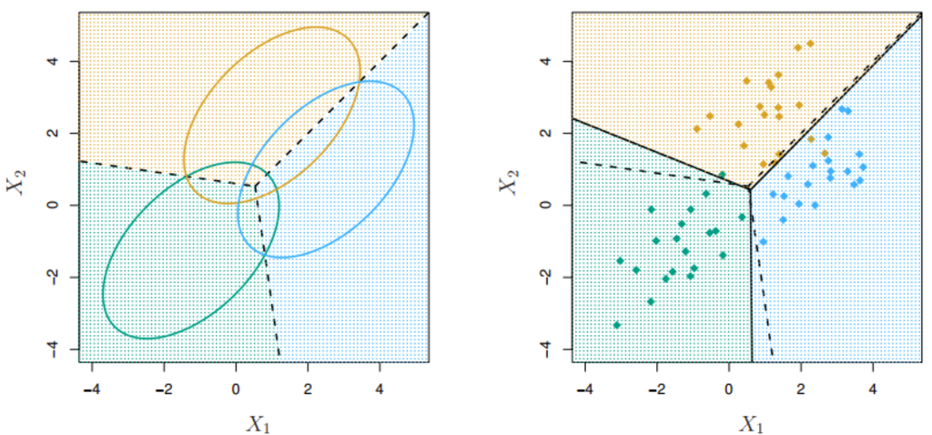

(Figura 4.6 de [ISLP]) Exemplo com três classes, dados normalmente distribuídos em cada classe, com $p = 2$. Esquerda: Elipses que contém 95% da probabilidade para cada uma das três classes e linhas pontilhadas representam as fronteiras de decisão do classificador de Bayes; Direita: 20 observações de cada classe e fronteiras de decisão do classificador LDA (linha contínua).

## Análise de discriminante quadrático (QDA)

- $\mathbf{X} | (Y = d)$ tem sua própria média e matriz de covariância:
  $$\mathbf{X} | (Y = d) \sim N(\boldsymbol{\mu}_d, \boldsymbol{\Sigma}_d)$$
- Parâmetros estimados por máxima verossimilhança:
  $$\begin{align*} \widehat{\boldsymbol{\mu}}_{d} &= \frac{1}{|\mathcal{C}_d|} \sum_{k \in \mathcal{C}_d} \mathbf{x}_{k} \\ \widehat{\boldsymbol{\Sigma}}_d &= \frac{1}{|\mathcal{C}_d|} \sum_{k \in \mathcal{C}_d} (\mathbf{x}_k - \widehat{\boldsymbol{\mu}}_d)(\mathbf{x}_k - \widehat{\boldsymbol{\mu}}_d)^T \end{align*}$$

## Análise de discriminante quadrático

- Podemos então considerar o classificador *plug-in*:
  $$\begin{align*} g(\mathbf{x}) &= \mathrm{argmax}_{d \in \mathcal{C}} \widehat{\mathbb{P}}(Y = d | \mathbf{X} = \mathbf{x}) \\ &= \mathrm{argmax}_{d \in \mathcal{C}} \widehat{q}(\mathbf{x} | Y = d)\widehat{\mathbb{P}}(Y = d) \\ &= \mathrm{argmax}_{d \in \mathcal{C}} \widehat{\delta}_d(\mathbf{x}) \end{align*}$$
- $\widehat{\delta}_d$ são as **funções discriminante** (*quadráticas* em $\mathbf{x}$!):
  $$\begin{align*} \widehat{\delta}_d(\mathbf{x}) &= -\frac{1}{2}\ln(\det(\widehat{\boldsymbol{\Sigma}}_d)) - \frac{1}{2} \mathbf{x}^T \widehat{\boldsymbol{\Sigma}}_d^{-1} \mathbf{x} \\ &+ \widehat{\boldsymbol{\mu}}_d^T \widehat{\boldsymbol{\Sigma}}_d^{-1} \mathbf{x} - \frac{1}{2}\widehat{\boldsymbol{\mu}}_d^T \widehat{\boldsymbol{\Sigma}}_d^{-1} \widehat{\boldsymbol{\mu}}_d + \ln(\widehat{\mathbb{P}}(Y = d)) \end{align*}$$

## Análise de discriminante quadrático (QDA)

- $\widehat{\delta}_d(\mathbf{x})$ *quadráticas* em $\mathbf{x}$
- As fronteiras de decisão $\{\mathbf{x} | \delta_d(\mathbf{x}) = \delta_c(\mathbf{x})\}$ são superfícies quádricas em $\mathbb{R}^p$
- Vejamos uma ilustração

## Análise de discriminante quadrático (QDA)

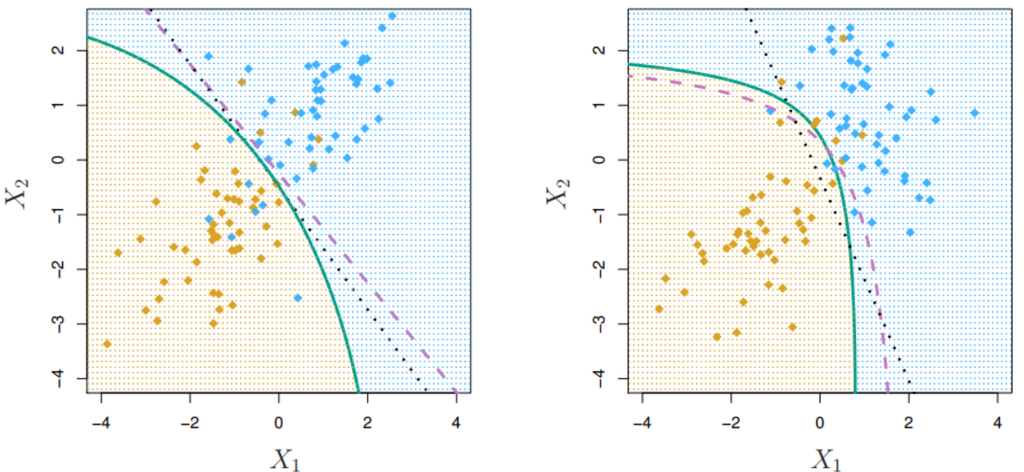

Figura 4.9 de [ISLP]) Fronteiras de decisão do classificador de Bayes (tracejado roxo), LDA (pontilhado preto) e QDA (linha verde contínua) com duas classes. Esquerda: $\boldsymbol{\Sigma}_1 = \boldsymbol{\Sigma}_2$; direita: $\boldsymbol{\Sigma}_1 \neq \boldsymbol{\Sigma}_2$.

## LDA ou QDA: qual escolher?

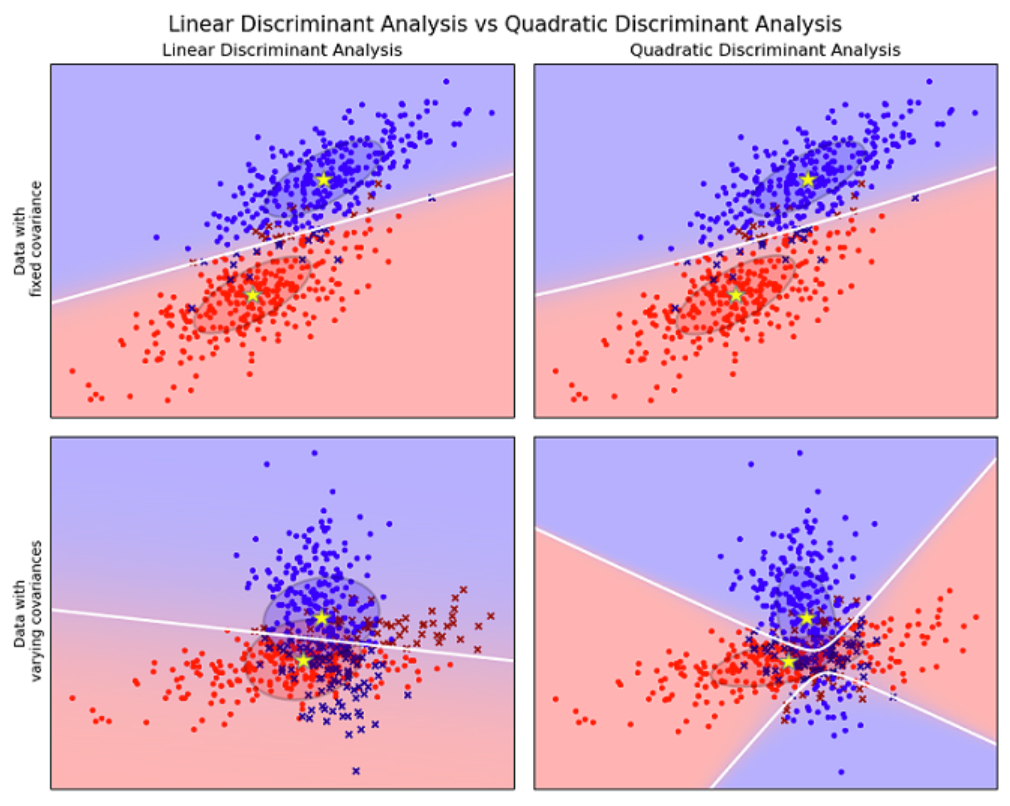

Retirada da página do `scikit-learn`. Comparação entre LDA e QDA.

## LDA ou QDA: qual escolher?

- $K$ classes e $p$ preditores
- LDA estima $Kp + p(p + 1)/2$ parâmetros:
  $$\boldsymbol{\mu}_1, \dots, \boldsymbol{\mu}_K ~ \mathrm{ e } ~ \boldsymbol{\Sigma}$$
- QDA estima $Kp + Kp(p + 1)/2$ parâmetros:
  $$\boldsymbol{\mu}_1, \dots, \boldsymbol{\mu}_K ~ \mathrm{ e } ~ \boldsymbol{\Sigma}_1, \dots, \boldsymbol{\Sigma}_K$$

## LDA ou QDA: qual escolher?

- LDA estima menos parâmetros que QDA $\implies$ menos flexível/maior viés
- Por outro lado, requer menos dados para seu treinamento $\implies$ “menos sensível ao conjunto de dados”/menor variância
- QDA estima *mais* parâmetros que LDA $\implies$ *mais* flexível/menor viés
- portanto requer *mais* dados para seu treinamento $\implies$ “mais sensível ao conjunto de dados”/maior variância

## LDA ou QDA: qual escolher?

- LDA **pode** ser melhor que QDA se “poucas” amostras de treinamento estão disponíveis
- QDA **pode** ser melhor se o conjunto de treinamento é “grande” ou a hipótese de $\boldsymbol{\Sigma}$ constante é inverossímil